# assignment_3

```r
houses <- read_csv("Melbourne_housing_FULL.csv")
houses <- houses %>%
  select(Price, Rooms, Type, Distance, Bedroom2, Bathroom)
```

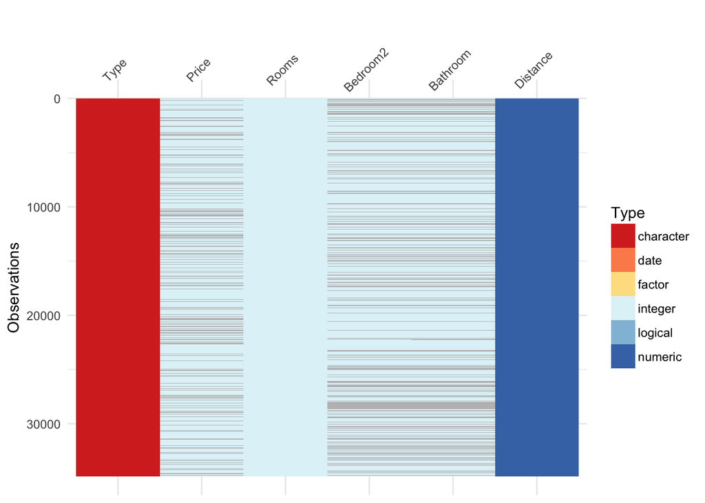

```r
vis_dat(houses, palette = "cb_safe")
```

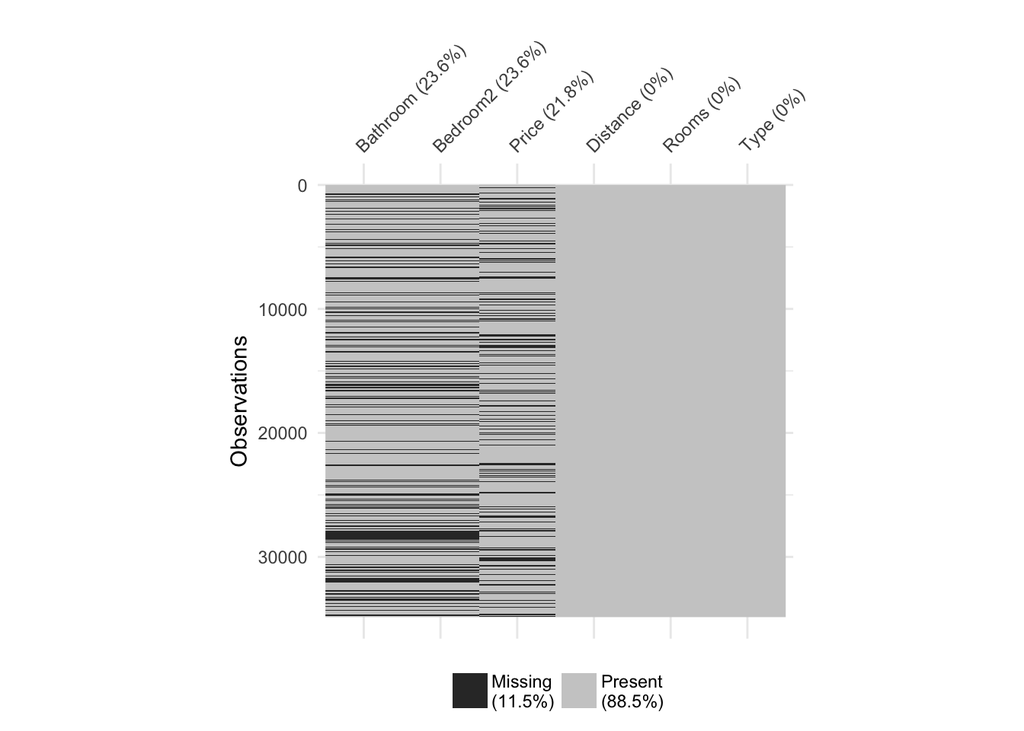

```r
vis_miss(houses, sort_miss=TRUE) + theme(aspect.ratio=1)
```

```r
s_miss <- miss_summary(houses)
s_miss$miss_case_table
```

```
## [[1]]
## # A tibble: 4 x 3
##   n_miss_in_case n_cases pct_miss
##            <int>   <int>    <dbl>
## 1              0   20800    59.7
## 2              1    5837    16.7
## 3              2    6443    18.5
## 4              3    1777     5.10
```

```r
s_miss_group <- houses %>%
  group_by(Type) %>% miss_summary()
s_miss_group$miss_case_table
```

```
## [[1]]
## # A tibble: 12 x 4
##    Type  n_miss_in_case n_cases pct_miss
##    <chr>          <int>   <int>    <dbl>
##  1 h                  0   15728    65.6
##  2 h                  1    4691    19.6
##  3 h                  2    2743    11.4
##  4 h                  3     818     3.41
##  5 u                  0    3493    47.9
##  6 u                  1     780    10.7
##  7 u                  2    2415    33.1
##  8 u                  3     609     8.35
##  9 t                  0    1579    44.1
## 10 t                  1     366    10.2
## 11 t                  2    1285    35.9
## 12 t                  3     350     9.78
```

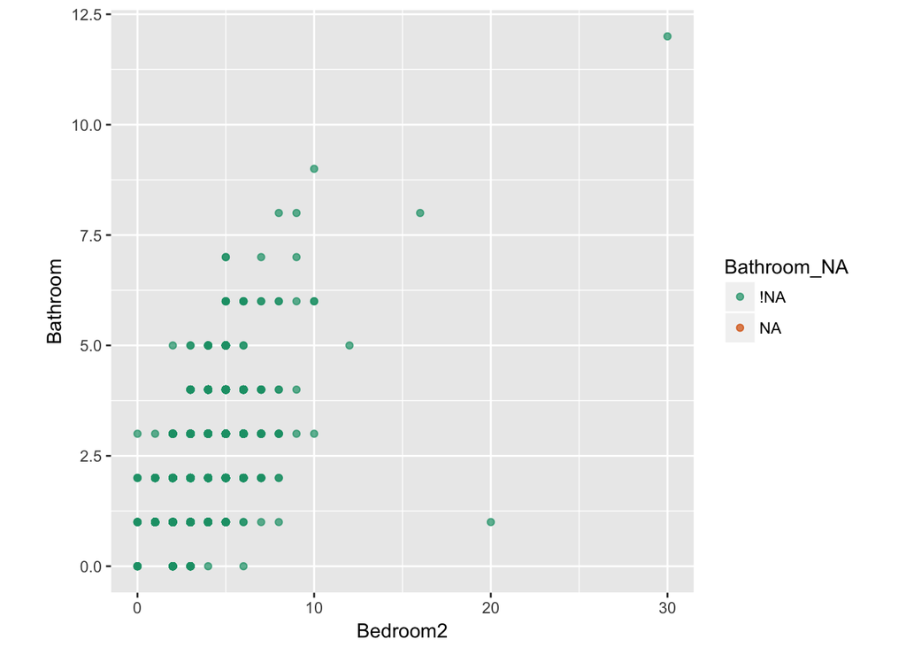

```r
houses_shadow <- bind_shadow(houses)
ggplot(data = houses_shadow,
       aes(x = Bedroom2, Bathroom, colour=Bathroom_NA)) +
  scale_colour_brewer(palette="Dark2") +
  geom_point(alpha=0.7) + theme(aspect.ratio=1)
```

##Missing Values Analysis

###### Looking at the number of observations missing values, its interesting to note that more observations miss two values than one. This is because values missing from Bedroom2 tend also to miss from bathroom. There is a very small number of cases in comparison to the number of data sets that have all three variables (Price, Bedroom2 and Bathroom) missing values in an observations.

```r
pricedata <- houses %>%
  select(Price, Rooms, Type, Bedroom2, Bathroom, Distance) %>%
  subset(!is.na(Bedroom2)) %>%
  subset(!is.na(Bathroom))
pricedata <-  pricedata %>%
  mutate(idnumb = as.numeric(row.names(pricedata)))


pricedatafixed <- pricedata%>%
  select(Price, Rooms, Type, Bathroom, Bedroom2, idnumb) %>%
  arrange(Price) %>%
  subset(is.na(Price)) %>%
  select(Rooms, Type, Bedroom2, Bathroom, idnumb)

pricedataexist <- pricedata%>%
  select(Price, Rooms, Type, Bathroom, Bedroom2, idnumb) %>%
  arrange(Price) %>%
  subset(!is.na(Price))

pricefit <- lm(Price~Rooms+Type+Bedroom2+Bathroom, data=pricedataexist)
tidy(pricefit)
```

```
##          term   estimate std.error  statistic       p.value
## 1 (Intercept)  382498.06 16732.250  22.859930 2.977452e-114
## 2       Rooms  149156.19 14731.642  10.124885  4.871771e-24
## 3       Typet -260110.36 15195.773 -17.117284  3.088226e-65
## 4       Typeu -322736.95 12398.894 -26.029495 5.177120e-147
## 5    Bedroom2  -36228.46 14354.603  -2.523822  1.161606e-02
## 6    Bathroom  273402.36  7156.074  38.205634 1.002429e-308
```

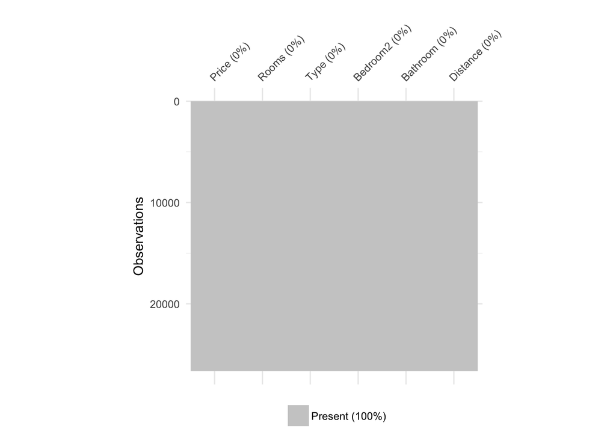

```r
pricedatafixed <- pricedatafixed %>%
  mutate( 'predicted_Price' = round(predict(pricefit, pricedatafixed))) %>%
  complete(idnumb = 1:26631)

datafitted <- pricedata %>%
  mutate( 'PredPrice' = pricedatafixed$predicted_Price) %>%
  transform(Price = pmax(Price, PredPrice, na.rm = TRUE)) %>%
  select(Price, Rooms, Type, Bedroom2, Bathroom, Distance)
vis_miss(datafitted, sort_miss=TRUE) + theme(aspect.ratio=1)
```

##Fixing NA Values

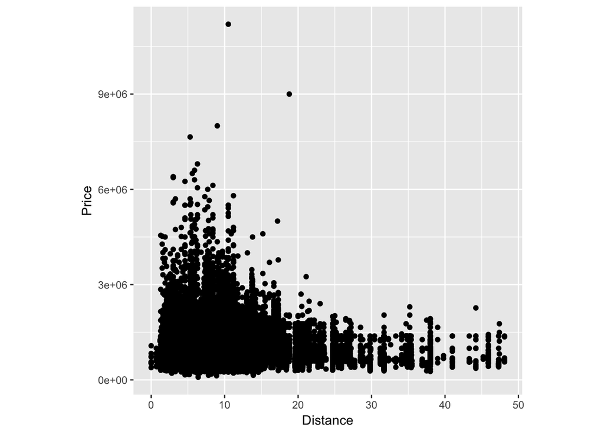

```r
ggplot(datafitted,
       aes(x = Distance,
           y = Price)) +
  scale_colour_brewer(palette="Dark2") +
  geom_point() +
  theme(aspect.ratio=1)
```

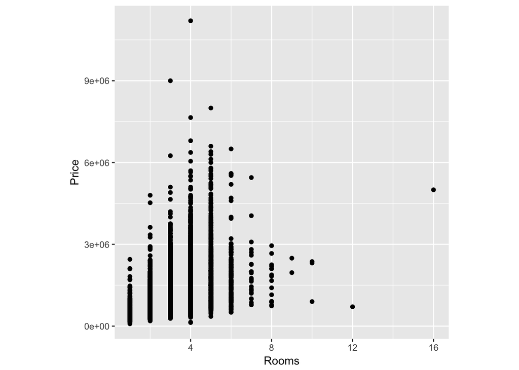

```r
ggplot(datafitted,
       aes(x = Rooms,
           y = Price)) +
  scale_colour_brewer(palette="Dark2") +
  geom_point() +
  theme(aspect.ratio=1)
```

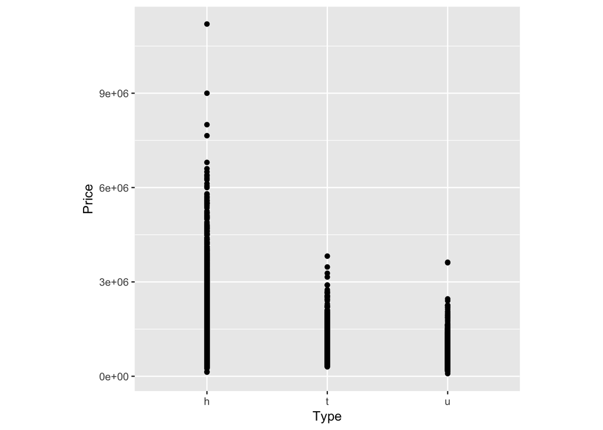

```r
ggplot(datafitted,
       aes(x = Type,
           y = Price)) +
  scale_colour_brewer(palette="Dark2") +
  geom_point() +
  theme(aspect.ratio=1)
```

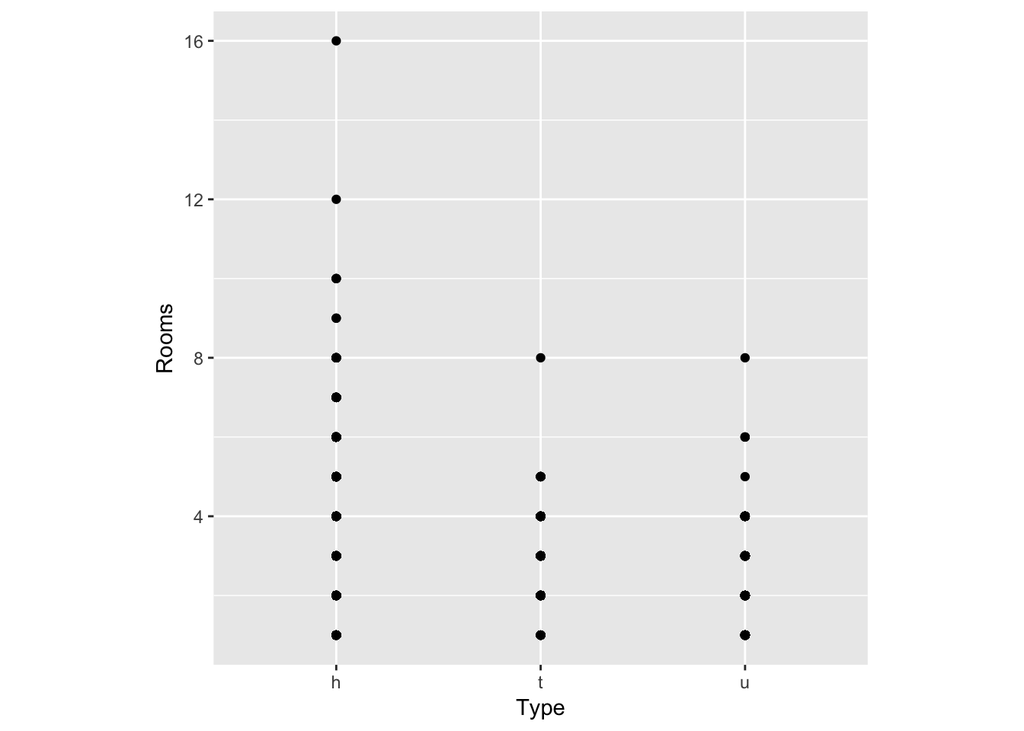

```r
ggplot(datafitted,
       aes(x = Type,
           y = Rooms)) +
  scale_colour_brewer(palette="Dark2") +
  geom_point() +
  theme(aspect.ratio=1)
```

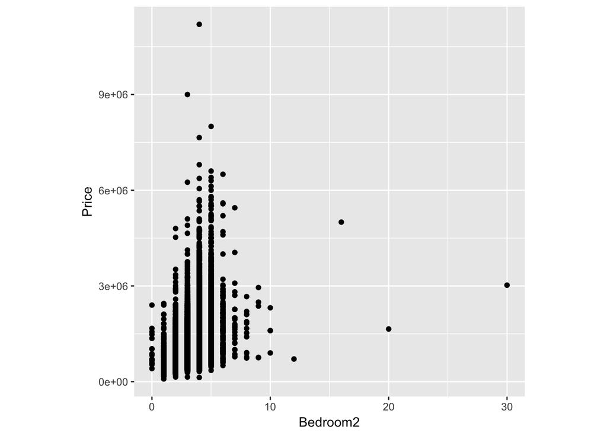

```r
ggplot(datafitted,
       aes(x = Bedroom2,
           y = Price)) +
  scale_colour_brewer(palette="Dark2") +
  geom_point() +
  theme(aspect.ratio=1)
```

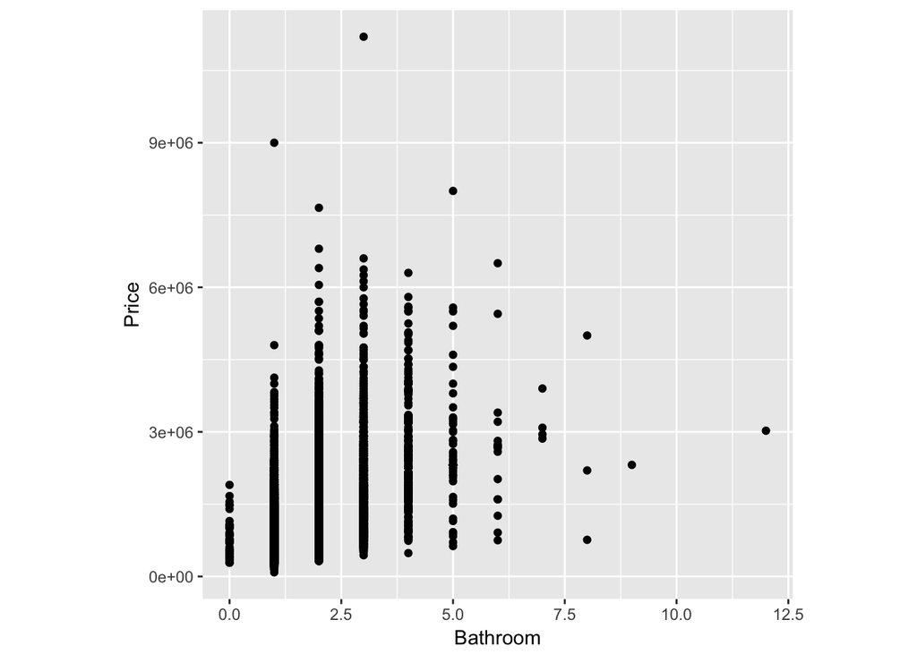

```r
ggplot(datafitted,
       aes(x = Bathroom,
           y = Price)) +
  scale_colour_brewer(palette="Dark2") +
  geom_point() +
  theme(aspect.ratio=1)
```

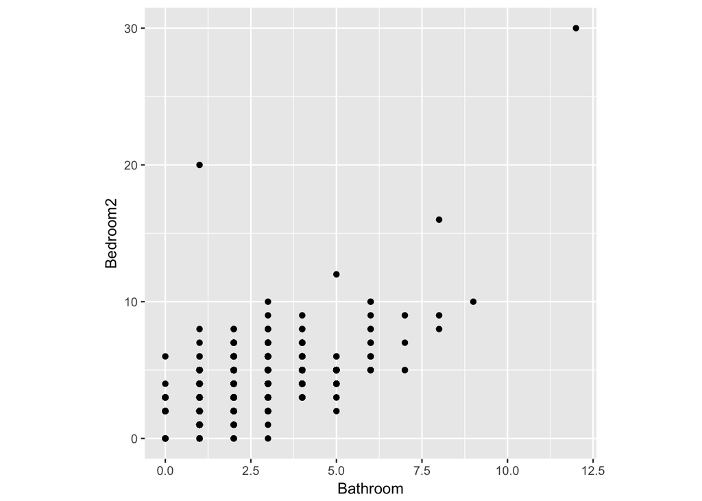

```r
ggplot(datafitted,
       aes(x = Bathroom,
           y = Bedroom2)) +
  scale_colour_brewer(palette="Dark2") +
  geom_point() +
  theme(aspect.ratio=1)
```

##Variable Decisions

###### Graph 5 and 6 look at the relationships between Bedroom2 and Price or Bathroom and Price. These both appear to be related to Price. The final graph looks at how they interact with each other which also appears to be very linear.

```r
modelfitted <- lm(Price ~ Type*Rooms + Bedroom2*Bathroom, data=datafitted)
tidy(modelfitted)
```

```
##                term    estimate std.error   statistic       p.value
## 1       (Intercept)  440685.621 18624.359  23.6617872 1.644279e-122
## 2             Typet -255143.865 50358.074  -5.0665930  4.077049e-07
## 3             Typeu -411113.628 28929.243 -14.2110054  1.150429e-45
## 4             Rooms  164303.240 11223.834  14.6387799  2.449798e-48
## 5          Bedroom2  -68914.137 12733.005  -5.4122444  6.277687e-08
## 6          Bathroom  248378.718  8687.078  28.5917450 4.050004e-177
## 7       Typet:Rooms   -2007.688 16762.251  -0.1197744  9.046628e-01
## 8       Typeu:Rooms   39236.295 12675.109   3.0955391  1.966593e-03
## 9 Bedroom2:Bathroom    7000.503  1780.180   3.9324701  8.429036e-05
```

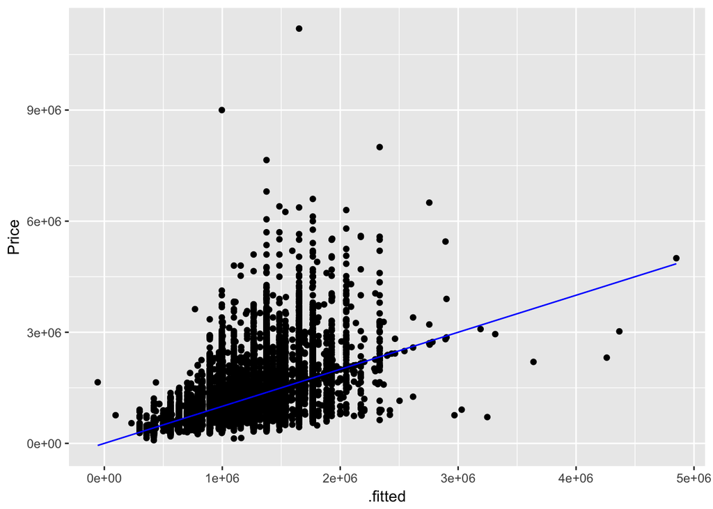

```r
model <- augment(modelfitted, datafitted)

ggplot(model, aes(x=.fitted, y=Price)) +
  geom_point() +
  geom_line(aes(y=.fitted), colour="blue")
```

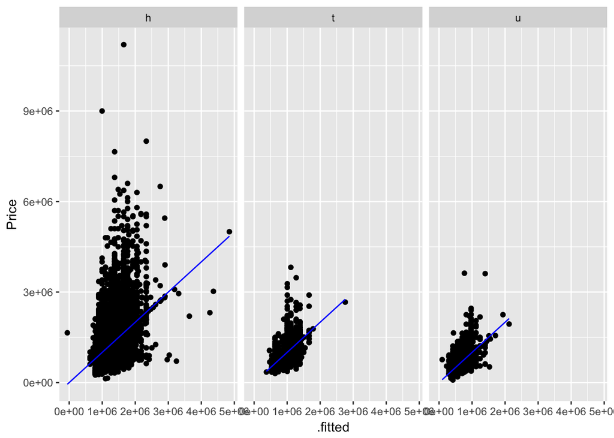

```r
ggplot(model, aes(x=.fitted, y=Price)) +
  geom_point() +
  facet_grid(~Type) +
  geom_line(aes(y=.fitted), colour="blue")
```

```r
glance(modelfitted)
```

```
##   r.squared adj.r.squared  sigma statistic p.value df    logLik      AIC
## 1 0.3266902     0.3264879 493570  1614.626       0  9 -386900.2 773820.4
##        BIC    deviance df.residual
## 1 773902.3 6.48542e+15       26622
```

# Model

###### The interactions between Rooms and Type, Bedroom2 and Bathroom were included in the model. Looking at the two graphs available show that the overall model fits quite well, given that there is an abundance of values close together. The second graph shows that the model is fitted best for units. Glimpsing the model shows however that the Rsquared term is quite low at 0.3267. This is due to the fact that there are many other variables that dictate how expensive a house/apartment/townhouse actually costs. These include location (such as suburb), newness of the house, and facilities (eg. pool, garage, tennis court). Given the fact that these variables were not taken into account a low Rsquared term is expected.